# Evolutionary epidemiology in the field: a proactive approach for identifying herbicide resistance in problematic crop weeds - Baucom - 2019 - New Phytologist - Wiley Online Library

[New Phytologist](https://nph.onlinelibrary.wiley.com/journal/14698137)

[Volume 223, Issue 3](https://nph.onlinelibrary.wiley.com/toc/14698137/2019/223/3) p. 1056-1058

[figure not shown]

Commentary

Free Access

# Evolutionary epidemiology in the field: a proactive approach for identifying herbicide resistance in problematic crop weeds

[Regina S. Baucom](https://nph.onlinelibrary.wiley.com/action/doSearch?ContribAuthorRaw=Baucom%2C+Regina+S),

[Roberto Busi](https://nph.onlinelibrary.wiley.com/action/doSearch?ContribAuthorRaw=Busi%2C+Roberto),

First published: 20 June 2019

https://doi.org/10.1111/nph.15959

Citations: 4

This article is a Commentary on [Comont *et al.,***223**: 1584–1594](https://doi.org/10.1111/nph.15800).

## Abstract

This article is a Commentary on [Comont *et al.,* **223**: 1584–1594](https://doi.org/10.1111/nph.15800).

Is the evolution of resistance to xenobiotics – chemicals designed to kill unwanted organisms – predictable? The repeated evolution of resistance across microbes (Lässig *et al*., 2017), insects (Pélissié *et al*., 2018) and weeds (Baucom, 2019) is an issue with major impacts on human health and food security. As such, understanding whether or not there are predictable features of this phenomenon is of great interest to many researchers. However, research on this topic is generally performed after resistance evolution has occurred and thus after the efficacy of the xenobiotic has been lost. Comparatively few investigations have considered the potential for resistance before the loss of control (e.g. Busi *et al*., 2012). In this issue of *New Phytologist*, Comont et al. (pp. 1584–1594) takes a preemptive, epidemiological perspective to examine the initial stages of herbicide resistance evolution in field populations of blackgrass (*Alopecurus myosuroides*). This work is both timely and novel – timely because the authors examine the potential for the evolution of resistance to glyphosate, a crucial herbicide used worldwide for weed control, and novel in that the work integrates the principles of evolutionary biology into a field-based, preemptive assay of resistance.

> *‘The novelty in the* *Comont* et al. *study lies in the combination of different levels of analysis …’*

The evolution of herbicide resistance is a consistent yet highly undesirable feature of herbicide use (Kniss, 2017). Although resistance to herbicides initially did not appear to evolve as rapidly as did cases of insecticide resistance (Gressel & Segel, 1978), over 240 weeds are now resistant to a variety of herbicides following *c*. 70 years of herbicide use (Heap, 2019). Weeds, which impose significant competition on crops, are one of the greatest global threats to crop production (Oerke, 2005); the evolution of herbicide resistance in weed populations thus means the loss of a very important tool of weed control for the farmer. The evolution of glyphosate resistance is particularly problematic given the worldwide adoption of transgenic glyphosate resistant crops (>180 million acres today) and the concomitant, increased reliance on this single herbicide (Duke & Powles, 2008). Currently, there are *c*. 41 weed species that have evolved resistance to glyphosate (Heap, 2019). Strikingly, what we have learned about glyphosate resistance evolution from these species all stems from studying the weeds after they become problematic to the farmer. This means that we are most often considering glyphosate resistance evolution in a reactive, rather than proactive fashion.

## Assessing the features of herbicide resistance evolution

To understand how the study of herbicide resistance after its evolution in the field may lead to knowledge gaps, we first have to understand how resistance to herbicide is practically diagnosed. Often, a farmer will suspect a weed population has evolved resistance and will contact an extension specialist/weed scientist after clear signs – sometimes across multiple years – that control by the herbicide is poor (Beckie *et al*., 2000). Additionally, the weed scientist may choose to assess the potential for resistance in a particular weed species using fields that have a history of long-term selection from a specific herbicide mechanism of action (Beckie *et al*., 2000). To diagnose resistance, the weed scientist will perform a dose-response experiment using a random subset of populations from the area of concern, including the problematic population, and a known susceptible control (Heap, 2005). The following conditions must be met for a weed species to be considered resistant: the potential resistant population shows a significantly different response compared to the susceptible control (usually higher survival or greater biomass post-herbicide); the resistance must be heritable; and the population is considered problematic to the farmer when the field dose of the herbicide is used (Burgos *et al*., 2013). These criteria for the formal designation of resistance are clearly aimed at focusing efforts on weeds that are problematic in the practical sense (> 10-fold difference in response compared to susceptible control).

The criteria for the evolution of resistance, however, are simpler than the criteria used to diagnose resistance. For resistance to evolve, a weed population needs only to have genetic variation underlying resistance and to experience consistent selection from herbicide. Thus, a formal designation of resistance, made after its evolution in the field, overlooks the evolutionary process leading to the resistance phenotype in the field. The work in Comont *et al*. is based on the idea that capturing the potential for resistance evolution – before the loss of control in the field – may ultimately inform proactive resistance management.

## A novel epidemiological approach

Blackgrass is a significant weed in most European grain fields and it is already resistant to herbicides targeting seven different sites of action (ACCase – A, ALS – B, PSII – C1, C2, VLCFAE – K3, lipid – N and microtubule synthesis – K1 inhibitors). It is yet to be identified as resistant to glyphosate, that is there are no reports that blackgrass populations are not controlled by the recommended field dose of glyphosate. Comont *et al*. combine screens of among- and within-population variability for glyphosate resistance across almost 100 field-sampled populations (Fig. 1). For the among-population component, the authors combine the historical record of seven years of glyphosate use across 96 different fields with assessment of population-level resistance values estimated from a replicated dose-response experiment (Fig. 1a,b). They show an eight-fold increase in glyphosate use from 1990 to 2014, and that the frequency of glyphosate use by farmers within these populations has likewise increased. Further, they show that the percentage mortality of populations ranges from 15% to 94% at an herbicide dose that is 0.75× the field rate, indicating that there is wide variation in sensitivity to this herbicide across the landscape (Fig. 1a). Tellingly, historical selection intensity from glyphosate was a significant predictor of a population's LD<sub>50</sub> value (the dose required to kill 50% of individuals within the population), indicating that populations had already responded to the use of the herbicide and increased in resistance over time. Comont *et al*. then capture the within-population dynamic by determining the heritability of glyphosate resistance using a typical quantitative genetics crossing design (Fig. 1b). Narrow-sense heritability values ranged from 0.27 to 0.28 across herbicide rates, indicating that the basic ‘script’ of evolution – genetic variation – was present within experimental populations and that further reduced glyphosate sensitivity could evolve. Additionally, the progeny of these crosses exhibited higher LD<sub>50</sub> values than the parents, indicating that the genetic variation present within lineages responded from one generation of selection by the herbicide (Fig. 1b).

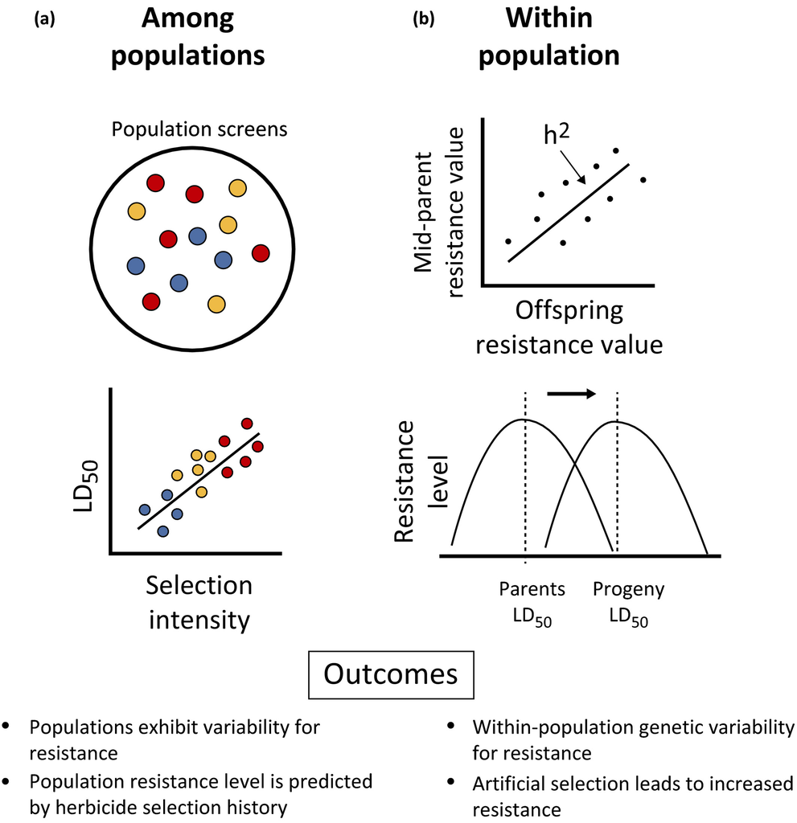

**Figure 1**

The work of Comont *et al*. (pp. 1584-1594) combines preemptive screens of (a) among-population and (b) within-population variation for glyphosate resistance in *c*. 100 populations of *Alopecurus myosuroides* (blackgrass) sampled from various locations in Europe. The work overall shows that populations have responded with increases in the level of resistance (as shown by population LD<sub>50</sub> value) and that additive genetic variation (*h*<sup>2</sup>) within the species responds to artificial selection with the herbicide.

The novelty in the Comont *et al*. study lies in the combination of different levels of analysis: they show the selection intensity is increasing and that populations have responded with decreased glyphosate sensitivity across many populations, and further, they demonstrate that the potential for continued evolutionary response is present within populations. Previous work has shown that the historical field dose is correlated to the level of resistance across populations (Gressel, 2009; Evans *et al*., 2016; Hicks *et al*., 2018) and that weed populations have the ability to respond to selection from glyphosate or other herbicides (Busi *et al*., 2012; Debban *et al*., 2015). As yet, however, no study has combined each of these components into one large and cohesive study, especially using a species that is yet to reach a threshold where it is considered glyphosate resistant.

Will such examinations inform us about the relative risk of highly problematic levels of resistance evolving in the field? The answer to this question is unknown, largely because, as explained earlier, the majority of our examinations occur in a reactive fashion, after a relatively high proportion of individuals exhibit resistance within a field. The proactive approach of Comont *et al*., however, could be very useful from a management perspective: populations exhibiting genetic variation for resistance, and an LD<sub>50</sub> value nearing the field dose should be managed differently from populations that were still well under the field dose. In these ‘high risk’ populations, farmers could switch to a different herbicide mechanism of action, or reduce herbicide use altogether for some time while adopting a ‘zero tolerance’ towards that particular field to stop weed seed set and onset the decline of the weed seed bank (Smith *et al*., 2015).

Performing proactive examinations – especially using well-known crop weeds and commonly-used herbicide mechanisms of action – could likewise be useful for investigating the predictability of resistance evolution in nature. There are plenty of examples wherein the same genetic basis underlies herbicide resistance (Baucom, 2016), suggesting that, in at least some cases, herbicide resistance evolution may be predictable (Lässig *et al*., 2017). Unfortunately, we know very little about the initial conditions within populations that may predispose them to resistance. Does every weed population exhibit additive genetic variation underlying resistance to a particular herbicide, and of those that might, does this variation respond to selection from the herbicide? Comprehensive analyses such as those in Comont *et al*. may also shed light on the observation that, despite being exposed to herbicide application for many years, some weed populations still do not exhibit high levels of herbicide resistance – what factors are responsible for the lack of resistance evolution (i.e. the limits on evolution)? Many questions remain about field-evolved resistance, and the work of Comont *et al*., which is modeled after proactive surveillance of antimicrobial resistance (Morrissey *et al*., 2013), provides a comprehensive path for assessing the likelihood of field-based resistance evolution.

## Acknowledgements

The authors thank T. Gaines and M. Vila-Aiub for providing feedback on this commentary. RB is funded by GRDC. RSB acknowledges funding from USDA-NIFA (grant no. 095224) and NSF (grant no. 094634).

## Citing Literature

[figure not shown]

[Volume223, Issue3](https://nph.onlinelibrary.wiley.com/toc/14698137/2019/223/3)

August 2019

Pages 1056-1058

beta

  Contrasting0

Explore this article's citation statements on [scite.ai](https://scite.ai/reports/evolutionary-epidemiology-in-the-field-n6jQOdn)

powered by

[figure not shown]

### Recommended

- [Evolutionary epidemiology predicts the emergence of glyphosate resistance in a major agricultural weed](https://nph.onlinelibrary.wiley.com/doi/full/10.1111/nph.15800)

  [New Phytologist](https://nph.onlinelibrary.wiley.com/journal/14698137)
- [Resistance to herbicides caused by single amino acid mutations in acetyl-CoA carboxylase in resistant populations of grassy weeds](https://nph.onlinelibrary.wiley.com/doi/full/10.1111/nph.12117)

  [New Phytologist](https://nph.onlinelibrary.wiley.com/journal/14698137)
- [Weeds of agricultural importance: bridging the gap between evolutionary ecology and crop and weed science](https://nph.onlinelibrary.wiley.com/doi/full/10.1111/j.1469-8137.2009.03077.x)

  [Regina S. Baucom](https://nph.onlinelibrary.wiley.com/action/doSearch?ContribAuthorRaw=Baucom%2C+Regina+S), [Jodie S. Holt](https://nph.onlinelibrary.wiley.com/action/doSearch?ContribAuthorRaw=Holt%2C+Jodie+S),

  [New Phytologist](https://nph.onlinelibrary.wiley.com/journal/14698137)
- [Adopting epidemiological approaches for herbicide resistance monitoring and management](https://onlinelibrary.wiley.com/doi/full/10.1111/wre.12420)

  [David Comont](https://nph.onlinelibrary.wiley.com/action/doSearch?ContribAuthorRaw=Comont%2C+David), [Paul Neve](https://nph.onlinelibrary.wiley.com/action/doSearch?ContribAuthorRaw=Neve%2C+Paul),

  [Weed Research](https://onlinelibrary.wiley.com/journal/13653180)

[back](https://nph.onlinelibrary.wiley.com/doi/full/10.1111/nph.15959)

[figure not shown]

4

0

hide